# Multivariate Analysis Task 1

Nzambuli Daniel

2024-01-27

# Question

Air pollution is currently one of the most serious public health worries worldwide. Many epidemiological studies have proved the influence that some chemical compounds can have on our health. Associations set up to monitor air quality are active all over the world to measure the concentration of these pollutants. They also keep a record of meteorological conditions such as temperature (T9, T12, T15), cloud cover (C9, C12, C15), wind (W9, W12, W15). The data set is within the `fdm2id` package.

The final aim is to analyse the relationship between the maximum daily ozone level and meteorological conditions. You have at our disposal 112 observations collected. You need to inspect the data with a PCA and illustrate the reconstruction property of PCA.

The variables available are

- max O3 (maximum daily ozone),
- Temperature at 0900HRS, 1200HRS & 1500HRS (T9, T12, T15)
- cloud cover at 0900HRS, 1200HRS & 1500HRS (C9, C12, C15)
- wind speed at 0900HRS, 1200HRS & 1500HRS (W9, W12, W15)

### The package

```r
library(fdm2id)
```

### The data

```r
data(airquality)
head(airquality)
```

```
##   Ozone Solar.R Wind Temp Month Day
## 1    41     190  7.4   67     5   1
## 2    36     118  8.0   72     5   2
## 3    12     149 12.6   74     5   3
## 4    18     313 11.5   62     5   4
## 5    NA      NA 14.3   56     5   5
## 6    28      NA 14.9   66     5   6
```

## Perform the PCA on the ozone data and give a short interpretation of the dimensions of variability (interpretation of the observations plot, correlation between variables, percentage of variability, etc.

### EDA

```r
any(is.na(airquality))
```

```
## [1] TRUE
```

```r
data = airquality
# quantity of data
cat("number of rows:", nrow(data), "\nnumber of cols:", ncol(data), "\nnumber of values:", nrow(data) * ncol(data))
```

```
## number of rows: 153
## number of cols: 6
## number of values: 918
```

The required data is 112 rows. Trying to omit `na` values to see if it fits

```r
data = na.omit(airquality)
nrow(data)
```

```
## [1] 111
```

There is a missing row.

### Correlation matrix

```r
cor_mat =cor(data)
cor_mat
```

```
##                Ozone     Solar.R        Wind       Temp        Month
## Ozone    1.000000000  0.34834169 -0.61249658  0.6985414  0.142885168
## Solar.R  0.348341693  1.00000000 -0.12718345  0.2940876 -0.074066683
## Wind    -0.612496576 -0.12718345  1.00000000 -0.4971897 -0.194495804
## Temp     0.698541410  0.29408764 -0.49718972  1.0000000  0.403971709
## Month    0.142885168 -0.07406668 -0.19449580  0.4039717  1.000000000
## Day     -0.005189769 -0.05775380  0.04987102 -0.0965458 -0.009001079
##                  Day
## Ozone   -0.005189769
## Solar.R -0.057753801
## Wind     0.049871017
## Temp    -0.096545800
## Month   -0.009001079
## Day      1.000000000
```

### Plot for clear view

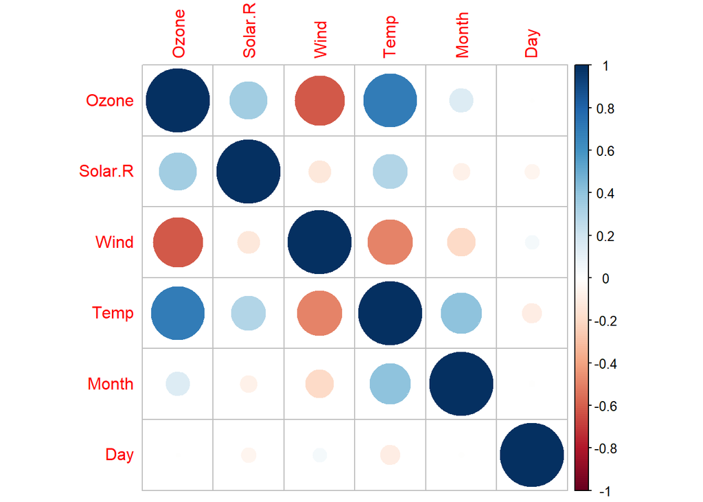

```r
library(corrplot)
corrplot(cor_mat)
```

> Seeing how the combined effect of temperature and ozone degrading impacts solar radiation will be interesting.

## PCA analysis

### Principle components(pc)

expecting `6` pc

```r
# Get the pc
princ_comp = prcomp(data, scale = TRUE) #mean 0 and sd 1

# extract the eigen vectors
princ_comp$rotation
```

```
##                 PC1         PC2         PC3        PC4          PC5         PC6
## Ozone    0.55674991 -0.14360812  0.14899189 -0.1896290  0.343950400 -0.70210158
## Solar.R  0.27511342 -0.65684217  0.06390617  0.5943327 -0.367286330  0.02561986
## Wind    -0.48136214 -0.06894019 -0.05796539  0.5551911  0.635805048 -0.21838616
## Temp     0.55816827  0.09983541 -0.04662790  0.1479575  0.514408229  0.62433938
## Month    0.25795060  0.71019446 -0.14263773  0.5190412 -0.279082504 -0.24788917
## Day     -0.06739663  0.16982064  0.97356959  0.1061941 -0.006924191  0.08634680
```

### Correct eigen value direction

```r
eig_val = -1 * princ_comp$rotation
eig_val
```

```
##                 PC1         PC2         PC3        PC4          PC5         PC6
## Ozone   -0.55674991  0.14360812 -0.14899189  0.1896290 -0.343950400  0.70210158
## Solar.R -0.27511342  0.65684217 -0.06390617 -0.5943327  0.367286330 -0.02561986
## Wind     0.48136214  0.06894019  0.05796539 -0.5551911 -0.635805048  0.21838616
## Temp    -0.55816827 -0.09983541  0.04662790 -0.1479575 -0.514408229 -0.62433938
## Month   -0.25795060 -0.71019446  0.14263773 -0.5190412  0.279082504  0.24788917
## Day      0.06739663 -0.16982064 -0.97356959 -0.1061941  0.006924191 -0.08634680
```

**Initial Overview**

> **PC1**
> - made up of mostly `ozone, wind, temperature`
> - temperature and ozone have a `direct relationship`
> - wind and ozone have an `inverse relationship`

> **PC2**
> - made up of mostly `solar radiation and month`
> - solar radiation and month have a `inverse relationship`

> **PC3**
> - mostly made up of `day`

> **PC4**
> - mostly `solar radiation, wind, month`

> **PC5**
> - mostly `wind and temperature`

> **PC6**
> - ozone and temperature

### Variance explained by each PC

```r
var_exp = princ_comp$sdev ^2 / sum(princ_comp$sdev ^2)
var_exp
```

```
## [1] 0.41147344 0.18552097 0.16639803 0.12804320 0.07078321 0.03778115
```

### Variance Explained Table

```r
var_exp_tab = data.frame(PC = c("PC1",
                                "PC2",
                                "PC3",
                                "PC4",
                                "PC5",
                                "PC6"),
                         var_exp = var_exp)

# cummulative variation explained
var_exp_tab$cum_sum = cumsum(var_exp)


# percentage variation explained
var_exp_tab$perc_exp = var_exp_tab$cum_sum *100

# view
var_exp_tab
```

```
##    PC    var_exp   cum_sum  perc_exp
## 1 PC1 0.41147344 0.4114734  41.14734
## 2 PC2 0.18552097 0.5969944  59.69944
## 3 PC3 0.16639803 0.7633924  76.33924
## 4 PC4 0.12804320 0.8914356  89.14356
## 5 PC5 0.07078321 0.9622188  96.22188
## 6 PC6 0.03778115 1.0000000 100.00000
```

### Find the Ideal PC to choose

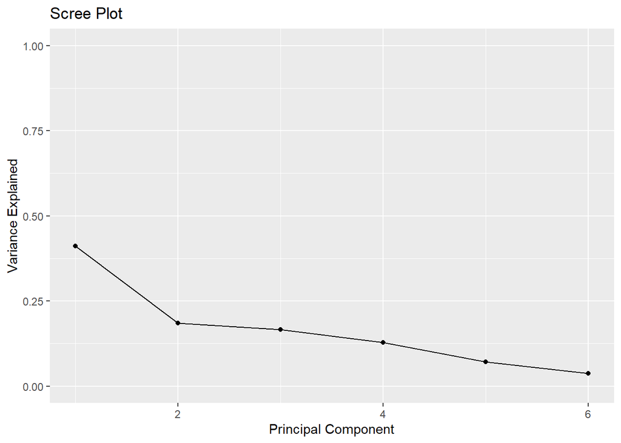

```r
library(ggplot2)
qplot(seq(1:6), var_exp)+
  geom_line() +
  labs(x ="Principal Component",
  y="Variance Explained",
  title = "Scree Plot") +
  ylim(0, 1)
```

The key pc to select are the first 3 pc

### Selecting only key components

```r
eig_val[, 1:3]
```

```
##                 PC1         PC2         PC3
## Ozone   -0.55674991  0.14360812 -0.14899189
## Solar.R -0.27511342  0.65684217 -0.06390617
## Wind     0.48136214  0.06894019  0.05796539
## Temp    -0.55816827 -0.09983541  0.04662790
## Month   -0.25795060 -0.71019446  0.14263773
## Day      0.06739663 -0.16982064 -0.97356959
```

### Plot Relationship

```r
library(factoextra)
```

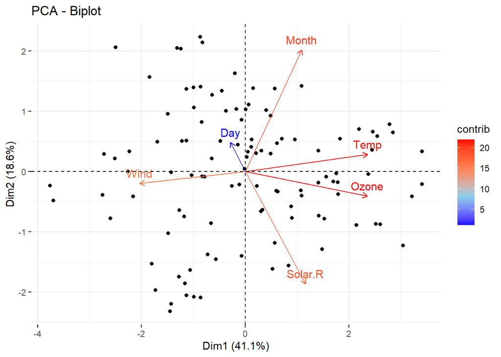

```r
fviz_pca_biplot(princ_comp,
                label = "var",
                col.ind = "black",
                col.var = "contrib",
                gradient.cols = c("blue","skyblue","coral","red"))
```

### explaining inference

> **Temperature and Time**